#### Note:

If you are still having trouble with the material covered so far recommend this tutorial. https://www.youtube.com/watch?v=Ldp3RmUxtOQ&ab_channel=codebliss

# Multi-Page Apps

This lecture is based on notes using this tutorial: https://towardsdatascience.com/beginners-guide-to-building-a-multi-page-dashboard-using-dash-5d06dbfc7599

Dash renders web applications as a "single-page app". This means that the application does not completely reload when the user navigates the application, making browsing very fast. Now that we’ve gone through the basics of building a single-page app, we can start working on the multi-page app — after all, a multi-page app is just an app with multiple single-page apps, but with some additional tweaks.

There are two ways to structure multi-page apps, see https://dash.plotly.com/urls for more information. But we will be looking at the method where each page is saved as a separate file.

File structure is very important when creating a mulitpage app. Here's how to structure a multi-page app, where each app is contained in a separate file. See https://dash.plotly.com/urls for more information

File structure:

```python
- app.py
- index.py
- apps
   |-- __init__.py
   |-- app1.py
   |-- app2.py
- assets
- datasets
```

The additional pages that we want to include is the app’s Landing Home page, the task123.py which is based on the MultiPlotsApp.py but with task 1, 2 & 3 added to it from lab. We will also create another single page app called Europe.py that will be shown later. Here is the structure to this Multi-Page Apps Folder

```python
- app.py
- index.py
- apps
    |-- __init__.py
    |-- home.py
    |-- task123.py
    |-- Europe.py
- assets
    |-- gapminderLogo.png
    |-- hansRoslin.jpeg
```

Let’s go through some of the files now.

### 1. apps folder

This is the folder where you include the individual files for each page of your app. Note that if you previously ran your file as a single-page app, you’ll need to make some changes if not you’ll run into a bunch of errors. These are commented out the parts that need to be changed in each file.

You’ll also need to create an empty file called **init**.py in this folder.

### 2. app.py file

The app.py file should look like this:

```python
import dash
import dash_bootstrap_components as dbc

# bootstrap theme
# https://bootswatch.com/lux/
external_stylesheets = [dbc.themes.LUX]

app = dash.Dash(__name__, external_stylesheets=external_stylesheets)

server = app.server
app.config.suppress_callback_exceptions = True
```

### 3. Styling the Dash app - the assests folder

All images and styling files such as CSS files should go inside the assets folder.

When it comes to styling the Dash app, there are a few options. You could use external stylesheets like this one or using: https://bootswatch.com/. One benefit of using Bootstrap is that they do have a built-in navigation bar function that you can use! Alternatively, you could build your own stylesheet (or modify one of the external stylesheets) too. All you have to do is to create a folder called “assets” and save your CSS file into that folder. Oh yes, if you’re planning to include images in your app, save them into the assets folder as well.

You can style your Dash app using Bootstrap, which is an open-source CSS framework used for web development. This means your apps are likely to be pretty aesthetically pleasing, without having to go through the hassle of building a CSS stylesheet from scratch.

https://dash-bootstrap-components.opensource.faculty.ai/

Here is a tutorial to learn more about how to style your app using Bootstrap: https://www.youtube.com/watch?v=0mfIK8zxUds&ab_channel=CharmingData

```python
pip install dash-bootstrap-components
```

#### Quick start with Bootstrap

```python
import dash
import dash_bootstrap_components as dbc

app = dash.Dash(
    external_stylesheets=[dbc.themes.BOOTSTRAP]
)

app.layout = dbc.Alert(
    "Hello, Bootstrap!", className="m-5"
)

if __name__ == "__main__":
    app.run_server()
```

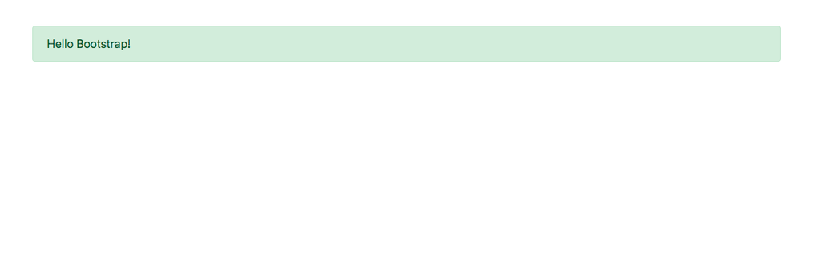

#### Bootstrap Grid System

The responsive grid system and the convenient container wrappers allow for a lot of customization. Bootstrap’s grid system uses a series of containers, rows, and columns to layout and align content. Those have been included as components in dash-bootstrap-components library as Container, Row, and Col. https://dash-bootstrap-components.opensource.faculty.ai/docs/components/layout/

The Row component is a wrapper for columns. The layout of your app should be built as a series of rows of columns. When using the grid layout, content should be placed in columns, and only Col components should be immediate children of Row.

The Bootstrap grid contains 12 columns and five tiers of responsiveness (allowing you to specify different behaviours on different screen sizes). The width of your columns can be specified in terms of how many of the twelve grid columns it should span, or you can allow the columns to expand or shrink to fit either their content or the available space in the row.

By setting different sizes, orders and offsets for the different responsive tiers you can build very complex layouts without the need for writing your own CSS or inline styles.

### 4. index.py file

One of the most important files, since this is the file that links up all the individual pages! A navigation bar has been added to the app in this file so that it’s easy to navigate across pages use bootstrap components, see for more information: https://dash-bootstrap-components.opensource.faculty.ai/docs/components/navbar/

```python
import dash_core_components as dcc
import dash_html_components as html
from dash.dependencies import Input, Output, State
import dash_bootstrap_components as dbc

from app import app
# import all pages in the app
from apps import MultiPlotsapp, home

# building the navigation bar
# https://github.com/facultyai/dash-bootstrap-components/blob/master/examples/advanced-component-usage/Navbars.py
dropdown = dbc.DropdownMenu(
    children=[
        dbc.DropdownMenuItem("Home", href="/home"),
        dbc.DropdownMenuItem("Global", href="/task1_2_3"),
        #dbc.DropdownMenuItem("Europe", href="/EuropePlots"),
    ],
    nav = True,
    in_navbar = True,
    label = "Explore Pages",
)

navbar = dbc.Navbar(
    dbc.Container(
        [
            html.A(
                # Use row and col to control vertical alignment of logo / brand
                dbc.Row(
                    [
                        dbc.Col(html.Img(src="/assets/gapminderLogo.png", height="30px")),
                        dbc.Col(dbc.NavbarBrand("Life Expectancy Dashboard", className="ml-2")),
                    ],
                    align="center",
                    no_gutters=True,
                ),
                href="/home",
            ),
            dbc.NavbarToggler(id="navbar-toggler2"),
            dbc.Collapse(
                dbc.Nav(
                    # right align dropdown menu with ml-auto className
                    [dropdown], className="ml-auto", navbar=True
                ),
                id="navbar-collapse2",
                navbar=True,
            ),
        ]
    ),
    color="dark",
    dark=True,
    className="mb-4",
)

def toggle_navbar_collapse(n, is_open):
    if n:
        return not is_open
    return is_open

for i in [2]:
    app.callback(
        Output(f"navbar-collapse{i}", "is_open"),
        [Input(f"navbar-toggler{i}", "n_clicks")],
        [State(f"navbar-collapse{i}", "is_open")],
    )(toggle_navbar_collapse)

# embedding the navigation bar
app.layout = html.Div([
    dcc.Location(id='url', refresh=False),
    navbar,
    html.Div(id='page-content')
])


@app.callback(Output('page-content', 'children'),
              [Input('url', 'pathname')])
def display_page(pathname):
    if pathname == '/task1_2_3':
        return task1_2_3.layout
    #elif pathname == '/EuropePlots':
    #    return EuropePlots.layout
    else:
        return home.layout

if __name__ == '__main__':
    app.run_server(port=8099,debug=True)
```

#### Create the Europe.py file using Bootstrap Container

```python
#import packages to create app
import dash
import dash_html_components as html
import dash_core_components as dcc
import dash_bootstrap_components as dbc
from dash.dependencies import Input, Output

from gapminder import gapminder

import plotly.express as px
import pandas as pd
import numpy as np

#data for the region plot
loc_data = px.data.gapminder()
loc_cols=list(loc_data.columns)
#get European data
eur_data =loc_data[loc_data['continent'] == "Europe"]
#get unique countries
country_names = eur_data['country'].unique()


color_discrete_map = {'Albania': '#000000', 'Austria': '#FFFF00', 'Belgium': '#1CE6FF',
    'Bosnia and Herzegovina': '#FF34FF','Bulgaria': '#FF4A46', 'Croatia': '#008941',
    'Czech Republic': '#006FA6', 'Denmark': '#A30059', 'Finland': '#FFDBE5',
    'France': '#7A4900', 'Germany': '#0000A6', 'Greece': '#63FFAC', 'Hungary': '#B79762',
    'Iceland': '#8FB0FF', 'Ireland': '#004D43','Italy': '#997D87', 'Montenegro': '#5A0007',
    'Netherlands': '#809693', 'Norway': '#FEFFE6', 'Poland': '#1B4400','Portugal': '#4FC601',
    'Romania': '#3B5DFF', 'Serbia': '#4A3B53', 'Slovak Republic': '#FF2F80',
    'Slovenia': '#61615A','Spain': '#BA0900', 'Sweden': '#6B7900', 'Switzerland': '#00C2A0',
    'Turkey': '#FFAA92','United Kingdom': '#FF90C9'}

# needed only if running this as a single page app
#from app import app
app = dash.Dash(__name__)
#change background and color text
colors = {
    #background to rgb(233, 238, 245)
    'background': '#e9eef5',
    'text': '#1c1cbd'
}



# change to app.layout if running as single page app instead
app.layout = html.Div(style={'backgroundColor': colors['background']},children=[
    dbc.Container([
        dbc.Row([
            #Header span the whole row
            #className: Often used with CSS to style elements with common properties.
            dbc.Col(html.H1("European Gapminder Data",
             style={
            'textAlign': 'center',
            'color': colors['text']}),
            className="mb-5 mt-5")
        ]),
        html.Div([
            html.Div([
                html.Label('Select Country/Countries'),
                dcc.Dropdown(id='country_dropdown',
                            options=[{'label': i, 'value': i}
                                    for i in country_names],
                            value=country_names,
                            multi=True
                )
            ],style={'width': '49%', 'display': 'inline-block'}),
            html.Div([
                html.Label('Select Population Range'),
                dcc.RangeSlider(id='eur_pop_range',
                    min=147962,
                    max=82400996,
                    value=[147962,82400996],
                    step= 1,
                    marks={
                        147962: '148K',
                        10000000: '10M',
                        50000000: '50M',
                        82400996: '82M'
                    },
                ),
                html.Label('Select Variable to display on the Graphs'),
                dcc.Dropdown(id='eur_y_dropdown',
                    options=[
                        {'label': 'Life Expectancy', 'value': 'lifeExp'},
                        {'label': 'Population', 'value': 'pop'},
                        {'label': 'GDP per Captia', 'value': 'gdpPercap'}],
                    value='lifeExp',
                )
            ],style={'width': '49%', 'float': 'right', 'display': 'inline-block'}),
        ]),
        html.Div([
            dcc.Graph(
                id='barchart'
            ),
            ],style={'width': '80%', 'margin-left': '10%','display': 'inline-block'}),
        html.Div([
            html.Div([
                dcc.Graph(
                        id='geochart'
                ),
            ],style={'width': '49%','display': 'inline-block'}),
            html.Div([
                dcc.Graph(
                    id='trendline'
                ),
            ],style={'width': '49%', 'float': 'right', 'display': 'inline-block'}),
            ]),
    ])
])


@app.callback(
    [Output(component_id='barchart', component_property='figure'),
    Output(component_id='geochart', component_property='figure'),
    Output(component_id='trendline', component_property='figure')],
    [Input(component_id='country_dropdown', component_property='value'),
    Input(component_id='eur_pop_range', component_property='value'),
    Input(component_id='eur_y_dropdown', component_property='value')]
)
def update_graphs(selected_count,erangevalue,eyvar):
    if not (selected_count or erangevalue or eyvar):
        return dash.no_update
    d = eur_data[(eur_data['pop'] >= erangevalue[0]) & (eur_data['pop'] <= erangevalue[1])]
    data =[]
    for j in selected_count:
            data.append(d[d['country'] == j])
    df = pd.DataFrame(np.concatenate(data), columns=loc_cols)
    df=df.infer_objects()
    barfig = px.bar(df, y=eyvar, x='country',animation_frame="year",
             # add text labels to bar
             text=eyvar, color='country',
             # different colour for each country
             color_discrete_map=color_discrete_map,
             # Add country and life Exp info to hover text
             hover_data=['lifeExp'],
             # change labels
             labels={'pop':'Population','country':'Country','lifeExp':'Life Expectancy'})
    #update text to be number format rounded with unit
    barfig.update_traces(texttemplate='%{text:.2s}')
    #update text to be font size 8 and hide if text can not stay with the uniform size
    barfig.update_layout(uniformtext_minsize=8, uniformtext_mode='hide',
        plot_bgcolor='rgb(233, 238, 245)',paper_bgcolor='rgb(233, 238, 245)',
        showlegend=False, margin=dict( b=200),xaxis_title="")
    barfig['layout']['updatemenus'][0]['pad']=dict(r= 10, t= 170)
    barfig['layout']['sliders'][0]['pad']=dict(r= 10, t= 170,)
    if eyvar == 'lifeExp':
         barfig.update_yaxes(range=[0, 85])
    elif eyvar == 'pop':
         barfig.update_yaxes(range=[0, erangevalue[1]])
    else:
         barfig.update_yaxes(range=[0, 50000])

    mapfig= px.choropleth(df,locations="iso_alpha", color=df[eyvar],
            hover_name="country",hover_data=['continent','pop'],animation_frame="year",
            color_continuous_scale='Turbo',range_color=[df[eyvar].min(), df[eyvar].max()],
            labels={'pop':'Population','year':'Year','continent':'Continent',
                'country':'Country','lifeExp':'Life Expectancy'})
    mapfig.update_layout(plot_bgcolor='rgb(233, 238, 245)',paper_bgcolor='rgb(233, 238, 245)')
    mapfig.update_geos(fitbounds="locations")
    mapfig.update_layout(margin={"r":0,"t":0,"l":0,"b":0})

    linefig = px.line(data_frame=df,
                x="year",  y = df[eyvar] , color='country',
                # different colour for each country
                color_discrete_map=color_discrete_map,
                hover_data=['pop','year'],
                 # Add bold variable in hover information
                  hover_name='country',
                 # change labels
                 labels={'pop':'Population','year':'Year','continent':'Continent',
                     'country':'Country','lifeExp':'Life Expectancy'})
    linefig.update_layout(plot_bgcolor='rgb(233, 238, 245)',
        paper_bgcolor='rgb(233, 238, 245)')

    return [barfig, mapfig, linefig]


# needed only if running this as a single page app
if __name__ == '__main__':
    app.run_server(port=8079,debug=True)
```

## Deploying the multi-page app on Heroku

Now that we’ve successfully built a multi-page app that runs well locally, let’s try and deploy it online so that we can share it with others. Here I will be just using Heroku as example of how to deploy online.

To see more information check out: https://dash.plotly.com/deployment and here is a good tutorial on using Heroku: https://www.youtube.com/watch?v=j3VvVaNnDH4&ab_channel=CampusX. Note this video and tutorial given earlier are using PyCharm to set up project here I set it all up in my folder.

### 1. Create a Heroku account

Head over to Heroku, https://www.heroku.com/home, create a free account and make sure to activate your account by clicking on the link that they’ll send to your email.

### 2. Set up git repository and install gunicorn

We first need to initialise an empty git repository, then we’ll need to install one more dependency, gunicorn, in order to allow for the deployment of our app.

### 3. Add a .gitignore file, Procfile and requirements.txt file

Please see the documentation from Heroku for more information: https://devcenter.heroku.com/categories/reference#deployment

The .gitignore file should look like this

```python
venv
*.pyc
.DS_Store
.env
```

The Procfile should look like this:

```python
web: gunicorn index:server
```

Note that index refers to the file, index.py and server refers to the variable server in that file. This brings me to my next point, you must add the following line in the index.py file in order for the app to be successfully deployed on Heroku.

```python
# must add this line in order for the app to be deployed successfully on Heroku
from app import server
```

The requirements.txt file gives a list of dependencies that your app requires. It can be automatically created using the following code.

```python
pip freeze > requirements.txt
```

### 4. Install Heroku Command Line Interface

If you’re using Mac, you can install this using Homebrew (but make sure Homebrew has been installed previously) by typing the following in Terminal: brew tap heroku/brew && brew install heroku If not, you can head over to this page to install it: https://devcenter.heroku.com/articles/heroku-cli#download-and-install

### 5. Deploy to Heroku

Run these commands on terminal

```python
# login to your Heroku account
heroku login

# change dash-app to a unique name
heroku create dash-app

# add files to git repository
git add *

# commit
git commit -m 'Initial Launch'

# deploy to Heroku
git push heroku master

# run the app with a 1 heroku "dyno"
heroku ps:scale web=1
```

You can view your app at https://dash-app.herokuapp.com, where dash-app is the name that you had chosen for your app.

You can access the app created for teaching this class here: https://sck1904.herokuapp.com/

Notice the difference in the two pages Global and Europe, where Europe has the layout wrapped in a dbc.Container

### 6. Updating your app

Just type the below code in the terminal where you’ve opened your App Folder whenever you make any changes to your app, be it updating your data, or changing the features in your app.

```python
git status # view the changes
git add .  # add all the changes
git commit -m 'a description of the changes'
git push heroku master
```